# Question 3- Data Translation Challenge

Brian Thomas, Madelyn Subali

6/6/2022

## Introduction

Retail needs to worry about who has money to spend - what has changed about who is working and earning money?

### Libraries and Data

```r
library(vtable)
library(ipumsr)
library(tidyverse)
library(purrr)
library(lubridate)
library(fixest)
library(multcomp)
library(dplyr)
library(rdrobust)

help("ipumsr")
ddi <- read_ipums_ddi("cps_00002.xml")
data <- read_ipums_micro(ddi)
```

```
## Use of data from IPUMS CPS is subject to conditions including that users should
## cite the data appropriately. Use command `ipums_conditions()` for more details.
```

## Data Cleaning

```r
cleandt <- data %>% dplyr :: select(YEAR, MONTH, EMPSTAT, OCC, IND, UHRSWORK1, WKSTAT)
cleandt <- cleandt %>% drop_na()
cleandt <- cleandt %>% mutate(HRSMAIN = UHRSWORK1)
# We filter for Employment Status at 10 (employed) and 20 (unemployed)
cleandt <- cleandt %>% filter(EMPSTAT %in% c(10,20:22))
# Denotes for the different months in the years of 2019 to 2022
cleandt <- cleandt %>% mutate(date = ym(paste(YEAR,MONTH)))

# Join the Industry names and cleandt to align broader Industries
indnames <- read_csv('indnames.csv')
cleandt <- cleandt %>% rename(ind = IND)
finaldt <- full_join(cleandt, indnames)
# Using binary variables where the industry of 'Retail Trade' will be 1, and others will be 0.
finaldt$industry <- ifelse(finaldt$indname == 'Retail Trade', 1, 0)
emp_rate_by_month <- finaldt %>%
  group_by(industry, date) %>%
  summarize(emp_rate = 1 - mean(EMPSTAT %in% 20:22))
emp_rate_by_month <- emp_rate_by_month %>%
  drop_na(industry) %>%
  drop_na(date)
```

## Visualization

Visualize the difference in the court of employed and unemployed people between those of the different industries.

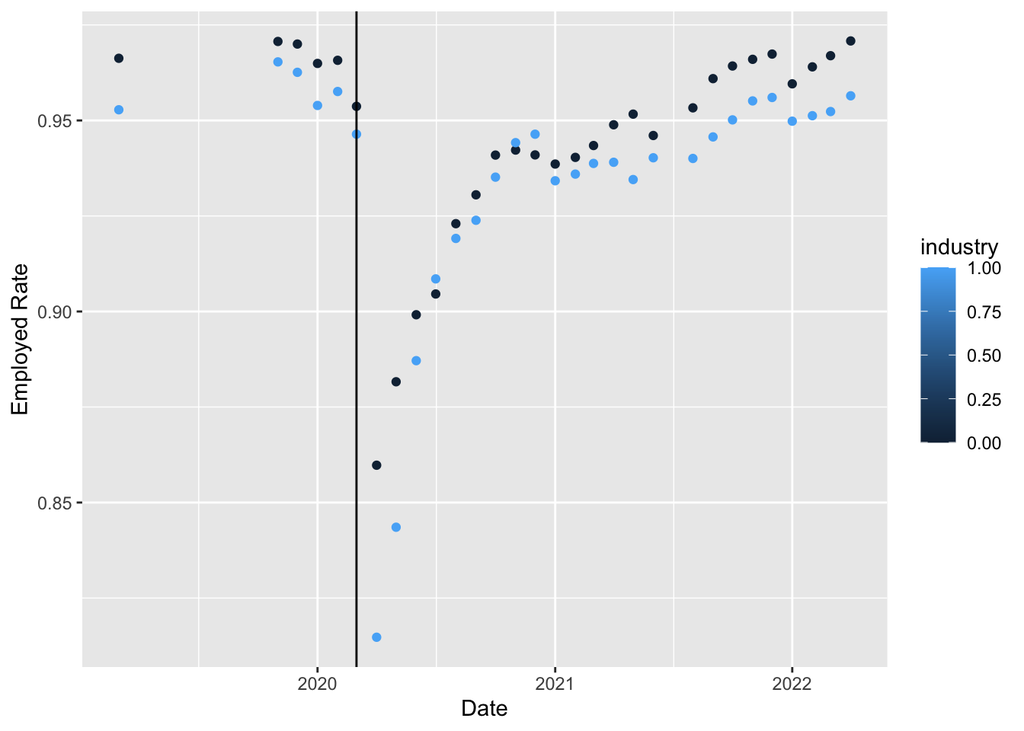

Creating bins of the Emp_Rate_By_Month

```r
bindata <- emp_rate_by_month  %>% mutate(emp_bins = cut(emp_rate, breaks = 36))
```

By viewing bindata, we get to find the bin located at the intercept in which COVID Started which was 2020-03-01.Using the emp_bins designated for the 2020-03-01 date variable “0.952,0.955” to explain the cutoff

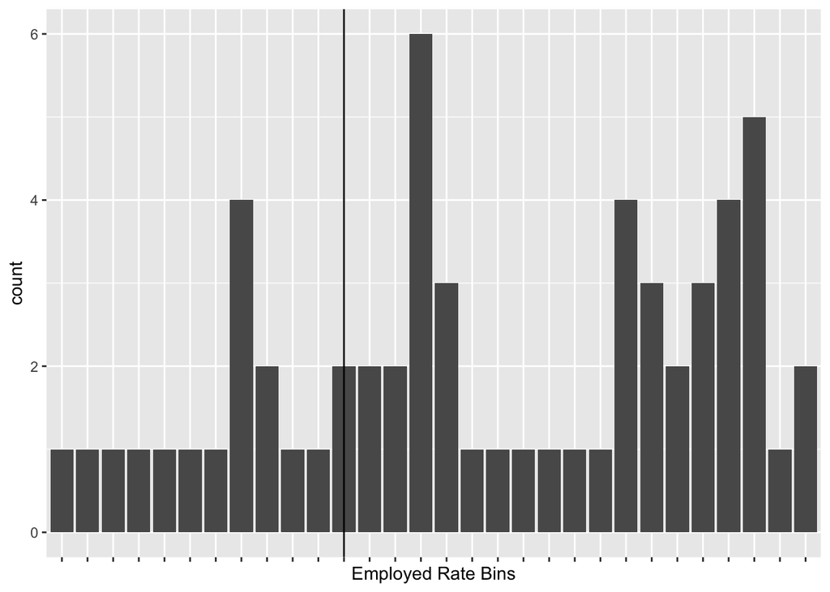

## Regression: Pre-COVID and Post-COVID

This will help select a window and weighting kernel to weight observations more near the cutoff. This is done by mutating two new variables called pre-covid and post-covid to access the effect of covid on employment rate

```r
treatment <- bindata %>% mutate(precovid = date < as.Date("2020-03-01"), postcovid = date > as.Date("2020-03-01"))

#use feols to look at a regression model to explain the difference
precovid <- feols(emp_rate ~ precovid, data = treatment)

postcovid <- feols(emp_rate ~ postcovid, data = treatment)
etable(precovid, postcovid, vcov = 'hetero')
```

```
##                           precovid           postcovid
## Dependent Var.:           emp_rate            emp_rate
##
## (Intercept)     0.9353*** (0.0045)  0.9608*** (0.0022)
## precovidTRUE    0.0276*** (0.0049)
## postcovidTRUE                      -0.0261*** (0.0051)
## _______________ __________________ ___________________
## S.E. type       Heteroskedas.-rob. Heteroskedast.-rob.
## Observations                    60                  60
## R2                         0.11477             0.11786
## Adj. R2                    0.09951             0.10265
## ---
## Signif. codes: 0 '***' 0.001 '**' 0.01 '*' 0.05 '.' 0.1 ' ' 1
```

#### Explanation on regression:

In precovid, we are looking at the impact of before COVID-19 happen which is before March 2020, where we see an increase in employment rate by 2.7%.

In postcovid, we are looking at how the overall impact of COVID-19 on employment rate. After March 2020, we see there is a decrease in employment rate by 2.6%.

## Regression: Before and After Vaccines

Now we want to look at the effect COVID-19 had on employment rate during when vaccines did not exist and how the employment rate improves since the launch of vaccines.

```r
novacstreat <- treatment %>% filter(date < as.Date("2021-01-01"))
covidnovacs <- feols(emp_rate ~ postcovid, data = novacstreat)

treatment <- treatment %>% mutate(postvacs = date > as.Date("2021-01-01"))
postvacs <- feols(emp_rate ~ postvacs, data = treatment)
etable(covidnovacs, postvacs)
```

```
##                         covidnovacs           postvacs
## Dependent Var.:            emp_rate           emp_rate
##
## (Intercept)      0.9608*** (0.0086) 0.9296*** (0.0051)
## postcovidTRUE   -0.0527*** (0.0111)
## postvacsTRUE                         0.0221** (0.0075)
## _______________ ___________________ __________________
## S.E. type                       IID                IID
## Observations                     30                 60
## R2                          0.44449            0.13173
## Adj. R2                     0.42465            0.11676
## ---
## Signif. codes: 0 '***' 0.001 '**' 0.01 '*' 0.05 '.' 0.1 ' ' 1
```

#### Explanation on regression:

In novacstreat, we are looking between when COVID-19 happen and before the vaccination was released, to see the impact of COVID-19 employment which has a 5% decrease.

In postvacs, we see that there is an overall positive increase in terms of employment rate after vaccination was released on early 2021, thus an increase by 2.2% on employment rate.

## Regression: Retail Industries

Now we want to look further at whether or not non-retail industries took a harder hit from Covid and benefited from vaccines.

```r
novacsind <- feols(emp_rate ~ postcovid*industry, data = novacstreat)

postvacsind <- feols(emp_rate ~ postvacs*industry, data = treatment)
etable(novacsind, postvacsind)
```

```
##                                   novacsind        postvacsind
## Dependent Var.:                    emp_rate           emp_rate
##
## (Intercept)              0.9652*** (0.0125) 0.9345*** (0.0072)
## postcovidTRUE            -0.0516** (0.0161)
## industry                   -0.0088 (0.0176)   -0.0098 (0.0102)
## postcovidTRUE x industry   -0.0023 (0.0228)
## postvacsTRUE                                  0.0229* (0.0105)
## postvacsTRUE x industry                       -0.0015 (0.0149)
## ________________________ __________________ __________________
## S.E. type                               IID                IID
## Observations                             30                 60
## R2                                  0.46197            0.16177
## Adj. R2                             0.39988            0.11686
## ---
## Signif. codes: 0 '***' 0.001 '**' 0.01 '*' 0.05 '.' 0.1 ' ' 1
```

## Visualization

Taking a look at the visualization again with linear lines explaining the effect

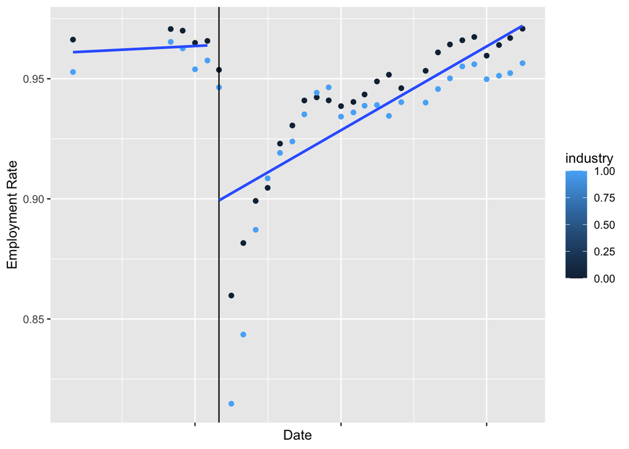

## Conclusion

Overall, this suggest that COVID-19 really took a hard impact on employment when the lockdowns happen and people started getting laid off. However, after the vaccine was released and the economy have improved, we see that the employment rate just keeps on increasing no matter the industry are as both retail and non-retail industry move in a similar direction.